# Advanced Statistical Analysis

Pour lire ce document plus confortablement, vous pouvez cliquer sur [ce lien](https://clementviolet.github.io/MEM_Analysis/).

## Introduction

La question biologique à laquelle on doit répondre est la suivante :

> Quelles sont les variables qui structurent cette communauté biologique ?

Le plan d’analyse est le suivant :

1. Chargement des packages, données et mise en forme des données :
   - Transformer les données floristiques par Hellinger ;
2. Partie Spatiale :
   - Récupérer les coordonnées géographiques ;
   - Créer une matrice de voisins ;
   - Créer une matrice de poids ;
   - Créer la matrice contenant les MEMs
   - Tester les MEMs ;
   - Tester l’autocorrélation spatiale des variables environnementales ;
   - Sélectionner les MEMs à conserver pour éviter la colinéarité et le surapprentissage (cf vignette `adespatial`) ;
   - Regarder le partitionnement de la variance
   - Faire une RDA en prenant en compte les données floristiques transformées et les MEMs
3. Partie environnementale
   - Faire une RDA sur les données floristiques et les variables environnementales ;
   - Sélectionner les variables environnementales à conserver ;
4. Mise en commun :
   - Faire une RDA des données floristiques avec les MEMs et les variables environnementales sélectionnées.
   - Interpréter les résultats

Le choix de l’analyse canonique s’est imposé à nous, car nous souhaitons expliquer un tableau de données floristiques par un autre tableau contenant des variables environnementales et certains Moran Eigenvector Map. Nous avons transformé les données du tableau de données floristiques par la transformation de Hellinger. Cette transformation permet une meilleure représentation des communautés lorsque l’on utilise des méthodes d’ordination (Legendre & Gallagher 2001). Nous avons également choisi d’utiliser comme méthode d’ordination la RDA puisque la méthode de la CCA a comme désavantage d’utiliser la distance du Khi-2 qui donne plus de poids aux différences d’abondances d’espèces rares. La distance du Khi-2 est décriée par certains auteurs comme étant la pire distance à utiliser en écologie (Faith et al. 1987), au contraire de la distance de Hellinger.

Pour prendre en compte la proximité spatiale des sites, nous avons choisi d’utiliser des vecteurs propres de Moran comme variables environnementales. Les vecteurs propres de ces matrices maximisent l’index de Moran pour prendre en compte l’autocorrélation spatiale.

## Chargement des packages, données et mise en forme des données

```r
library(tidyverse)
library(readxl)
library(ade4)
library(adespatial)
library(adegraphics)
library(spdep)
library(vegan)

source("triplot.rda.R")
```

```r
flo   <- read_excel("data_vegetation_french.xls", sheet = "flo")
mil   <- read_xls("data_vegetation_french.xls", sheet = "mil", col_types = "numeric") %>%
         janitor::clean_names() # Fait en sorte que les noms s'affichent correctement.
coord <- read_xls("data_vegetation_french.xls", sheet = "coord", col_types = "numeric")
asso  <- read_xls("data_vegetation_french.xls", sheet = "association") %>%
         mutate(association = as.factor(.$association))

str(flo)
```

```
## Classes 'tbl_df', 'tbl' and 'data.frame':    97 obs. of  56 variables:
##  $ E1 : num  0 5 4 0 0 0 0 0 5 0 ...
##  $ E2 : num  0 0 0 0 0 0 0 0 0 0 ...
##  $ E3 : num  0 0 2 0 0 0 0 0 1 0 ...
##  $ E4 : num  0 0 0 0 0 1 1 0 2 0 ...
##  $ E5 : num  0 1 1 0 0 0 0 0 1 0 ...
##  $ E6 : num  0 0 0 0 0 0 0 0 0 0 ...
##  $ E7 : num  0 0 0 0 0 0 0 0 0 0 ...
##  $ E8 : num  0 0 0 0 0 0 0 0 0 0 ...
##  $ E9 : num  0 0 0 0 0 0 0 0 0 0 ...
##  $ E10: num  0 0 0 0 0 0 0 0 0 0 ...
##  $ E11: num  0 0 0 0 0 0 0 0 0 0 ...
##  $ E12: num  1 0 0 0 0 0 0 2 0 1 ...
##  $ E13: num  1 0 0 1 0 0 0 1 0 1 ...
##  $ E14: num  0 0 0 0 0 0 0 1 0 0 ...
```

[output cut: 42 more lines]

```r
str(mil)
```

```
## Classes 'tbl_df', 'tbl' and 'data.frame':    97 obs. of  11 variables:
##  $ argile    : num  73 75 74 23 73 72 52 42 74 53 ...
##  $ limon     : num  24 24 24 26 24 22 46 49 24 44 ...
##  $ sable     : num  3 2 2 49 3 3 2 8 2 4 ...
##  $ k2o       : num  1.3 0.8 1.7 0.3 1.3 1.7 0.8 1.4 1.7 1.4 ...
##  $ mg        : num  9.2 10.7 8.6 2 9.2 6 6 19.6 8.6 17 ...
##  $ na_100g   : num  4.2 10.4 10.8 1.2 4.2 10.7 18.4 2.5 10.8 11.7 ...
##  $ k         : num  1.2 1.4 1.9 0.3 1.2 1.3 2.2 1.3 1.9 0.5 ...
##  $ conduc    : num  7.9 11.5 10.4 0.6 7.9 14.5 15.2 2.9 10.4 16.9 ...
##  $ capa_reten: num  41.8 42.4 41.4 22.3 41.8 42.7 37.4 35.4 41.4 38 ...
##  $ na_l      : num  48.7 66 24 2.2 48.7 ...
##  $ altitude  : num  6 2 2 6 6 4 4 3 3 6 ...
```

```r
summary(flo)
```

```
##        E1              E2               E3               E4
##  Min.   :0.000   Min.   :0.0000   Min.   :0.0000   Min.   :0.0000
##  1st Qu.:0.000   1st Qu.:0.0000   1st Qu.:0.0000   1st Qu.:0.0000
##  Median :0.000   Median :0.0000   Median :0.0000   Median :0.0000
##  Mean   :1.299   Mean   :0.3299   Mean   :0.3918   Mean   :0.4536
##  3rd Qu.:3.000   3rd Qu.:0.0000   3rd Qu.:0.0000   3rd Qu.:1.0000
##  Max.   :6.000   Max.   :5.0000   Max.   :4.0000   Max.   :3.0000
##        E5               E6                E7                E8
##  Min.   :0.0000   Min.   :0.00000   Min.   :0.00000   Min.   :0.00000
##  1st Qu.:0.0000   1st Qu.:0.00000   1st Qu.:0.00000   1st Qu.:0.00000
##  Median :0.0000   Median :0.00000   Median :0.00000   Median :0.00000
##  Mean   :0.1031   Mean   :0.09278   Mean   :0.09278   Mean   :0.06186
##  3rd Qu.:0.0000   3rd Qu.:0.00000   3rd Qu.:0.00000   3rd Qu.:0.00000
##  Max.   :2.0000   Max.   :2.00000   Max.   :2.00000   Max.   :2.00000
##        E9              E10              E11               E12
##  Min.   :0.0000   Min.   :0.0000   Min.   :0.00000   Min.   :0.0000
##  1st Qu.:0.0000   1st Qu.:0.0000   1st Qu.:0.00000   1st Qu.:0.0000
##  Median :0.0000   Median :0.0000   Median :0.00000   Median :0.0000
##  Mean   :0.2371   Mean   :0.1031   Mean   :0.07216   Mean   :0.3196
##  3rd Qu.:0.0000   3rd Qu.:0.0000   3rd Qu.:0.00000   3rd Qu.:0.0000
##  Max.   :4.0000   Max.   :2.0000   Max.   :2.00000   Max.   :3.0000
##       E13              E14               E15              E16
##  Min.   :0.0000   Min.   :0.00000   Min.   :0.0000   Min.   :0.00000
##  1st Qu.:0.0000   1st Qu.:0.00000   1st Qu.:0.0000   1st Qu.:0.00000
##  Median :0.0000   Median :0.00000   Median :0.0000   Median :0.00000
##  Mean   :0.4742   Mean   :0.06186   Mean   :0.2268   Mean   :0.04124
##  3rd Qu.:1.0000   3rd Qu.:0.00000   3rd Qu.:0.0000   3rd Qu.:0.00000
##  Max.   :2.0000   Max.   :1.00000   Max.   :2.0000   Max.   :1.00000
##       E17              E18              E19              E20
##  Min.   :0.0000   Min.   :0.0000   Min.   :0.0000   Min.   :0.0000
##  1st Qu.:0.0000   1st Qu.:0.0000   1st Qu.:0.0000   1st Qu.:0.0000
##  Median :0.0000   Median :0.0000   Median :0.0000   Median :0.0000
##  Mean   :0.1649   Mean   :0.4845   Mean   :0.8144   Mean   :0.3608
##  3rd Qu.:0.0000   3rd Qu.:0.0000   3rd Qu.:1.0000   3rd Qu.:1.0000
##  Max.   :3.0000   Max.   :5.0000   Max.   :5.0000   Max.   :2.0000
##       E21               E22               E23               E24
##  Min.   :0.00000   Min.   :0.00000   Min.   :0.00000   Min.   :0.00000
##  1st Qu.:0.00000   1st Qu.:0.00000   1st Qu.:0.00000   1st Qu.:0.00000
##  Median :0.00000   Median :0.00000   Median :0.00000   Median :0.00000
##  Mean   :0.01031   Mean   :0.09278   Mean   :0.08247   Mean   :0.08247
```

[output cut: 43 more lines]

```
##  Max.   :3.0000   Max.   :2.00000   Max.   :5.0000   Max.   :4.0000
##       E49               E50               E51               E52
##  Min.   :0.00000   Min.   :0.00000   Min.   :0.00000   Min.   :0.00000
##  1st Qu.:0.00000   1st Qu.:0.00000   1st Qu.:0.00000   1st Qu.:0.00000
##  Median :0.00000   Median :0.00000   Median :0.00000   Median :0.00000
##  Mean   :0.02062   Mean   :0.05155   Mean   :0.03093   Mean   :0.05155
##  3rd Qu.:0.00000   3rd Qu.:0.00000   3rd Qu.:0.00000   3rd Qu.:0.00000
##  Max.   :1.00000   Max.   :3.00000   Max.   :2.00000   Max.   :3.00000
##       E53               E54               E55               E56
##  Min.   :0.00000   Min.   :0.00000   Min.   :0.00000   Min.   :0.00000
##  1st Qu.:0.00000   1st Qu.:0.00000   1st Qu.:0.00000   1st Qu.:0.00000
##  Median :0.00000   Median :0.00000   Median :0.00000   Median :0.00000
##  Mean   :0.02062   Mean   :0.03093   Mean   :0.03093   Mean   :0.02062
##  3rd Qu.:0.00000   3rd Qu.:0.00000   3rd Qu.:0.00000   3rd Qu.:0.00000
##  Max.   :1.00000   Max.   :2.00000   Max.   :2.00000   Max.   :1.00000
```

```r
summary(mil)
```

```
##      argile          limon           sable             k2o
##  Min.   :18.00   Min.   :13.00   Min.   : 2.000   Min.   :0.200
##  1st Qu.:52.00   1st Qu.:22.00   1st Qu.: 3.000   1st Qu.:0.700
##  Median :62.00   Median :28.00   Median : 4.000   Median :1.100
##  Mean   :60.38   Mean   :30.02   Mean   : 8.495   Mean   :1.315
##  3rd Qu.:73.00   3rd Qu.:35.00   3rd Qu.: 7.000   3rd Qu.:1.600
##  Max.   :83.00   Max.   :67.00   Max.   :63.000   Max.   :4.000
##        mg          na_100g             k             conduc
##  Min.   : 2.0   Min.   : 0.700   Min.   :0.200   Min.   : 0.6
##  1st Qu.:10.0   1st Qu.: 4.100   1st Qu.:0.700   1st Qu.: 4.3
##  Median :13.5   Median : 6.800   Median :1.200   Median :11.3
##  Mean   :14.6   Mean   : 7.564   Mean   :1.497   Mean   :11.4
##  3rd Qu.:17.1   3rd Qu.:10.600   3rd Qu.:2.000   3rd Qu.:15.5
##  Max.   :31.4   Max.   :25.200   Max.   :5.100   Max.   :40.5
##    capa_reten         na_l           altitude
##  Min.   :14.60   Min.   :  2.20   Min.   :1.000
##  1st Qu.:35.30   1st Qu.: 24.00   1st Qu.:2.000
##  Median :38.80   Median : 57.60   Median :3.000
##  Mean   :38.55   Mean   : 63.94   Mean   :3.206
##  3rd Qu.:41.60   3rd Qu.: 94.00   3rd Qu.:4.000
##  Max.   :74.80   Max.   :253.80   Max.   :7.000
```

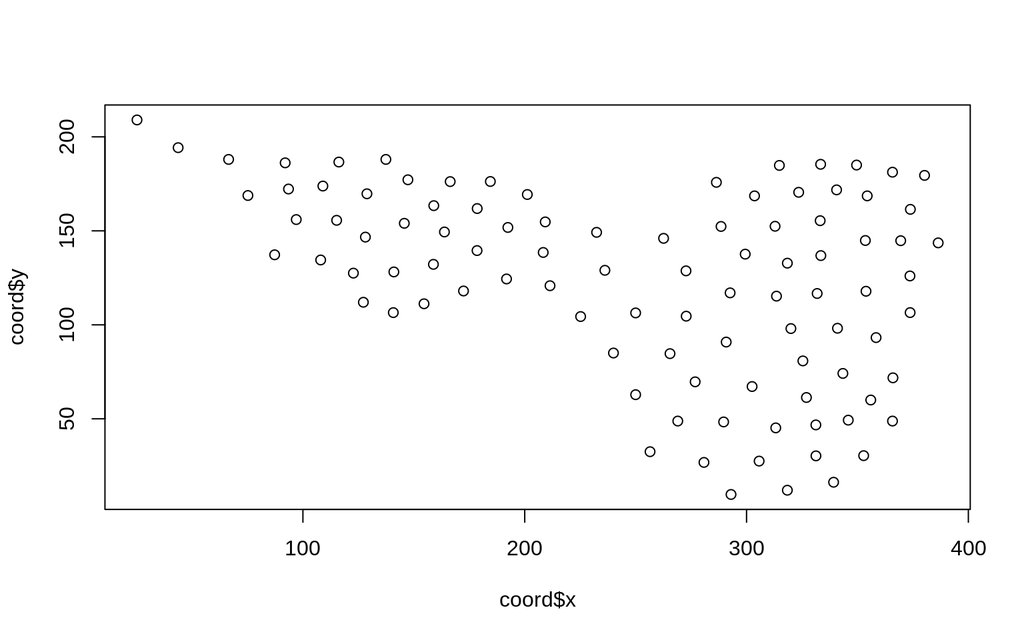

```r
plot(coord$x, coord$y)
```

Le graphique montre que le plan d’échantillonnage n’est pas régulier.

Centrage & réduction des données environnementales et transformation des données floristiques.

```r
flo_hell <- decostand(flo, method = "hell")

mil_scl <- as.data.frame(scale(mil))
```

## Partie Spatiale

```r
mxy <- as.matrix(coord) # Matrice contenant les coordonnes xy

nbgab <- graph2nb(gabrielneigh(mxy), sym = TRUE) # Utilisation de la methode de Gabriel
summary(nbgab)
```

```
## Neighbour list object:
## Number of regions: 97
## Number of nonzero links: 450
## Percentage nonzero weights: 4.782655
## Average number of links: 4.639175
## Link number distribution:
##
##  1  2  3  4  5  6  7
##  1  5 14 24 25 20  8
## 1 least connected region:
## 97 with 1 link
## 8 most connected regions:
## 10 24 28 59 67 78 79 81 with 7 links
```

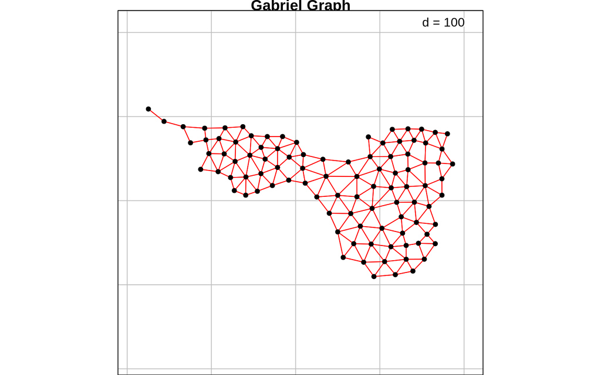

```r
s.label(mxy, nb = nbgab, pnb.edge.col = "red", main = "Gabriel Graph")
```

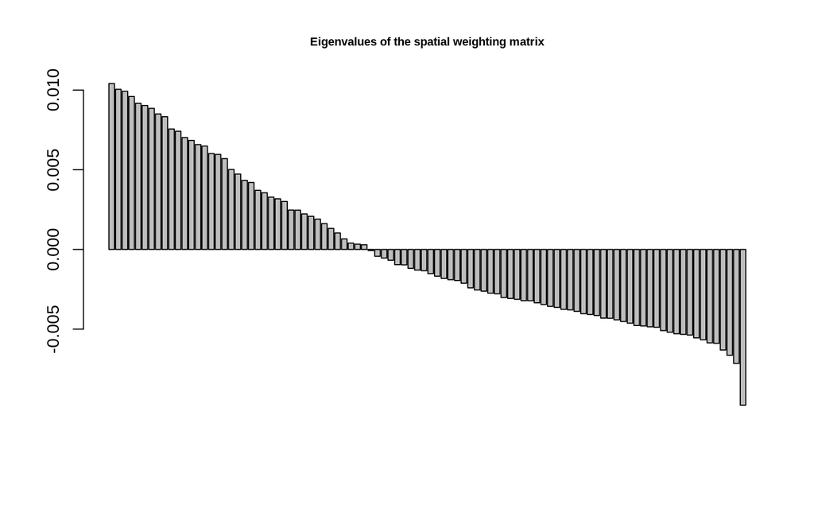

```r
listwgab <- nb2listw(nbgab) # Spatial weighting matrices

mem_gab <- mem(listwgab)

barplot(attr(mem_gab, "values"),
        main = "Eigenvalues of the spatial weighting matrix", cex.main = 0.7)
```

```r
moranI <- moran.randtest(mem_gab, listwgab, 999)
moranI
```

```
## class: krandtest lightkrandtest
## Monte-Carlo tests
## Call: moran.randtest(x = mem_gab, listw = listwgab, nrepet = 999)
##
## Number of tests:   96
##
## Adjustment method for multiple comparisons:   none
## Permutation number:   999
##     Test         Obs     Std.Obs   Alter Pvalue
## 1   MEM1  1.01002595  14.9120783 greater  0.001
## 2   MEM2  0.97459118  14.6074621 greater  0.001
## 3   MEM3  0.96272034  14.4257882 greater  0.001
## 4   MEM4  0.93079757  14.0434210 greater  0.001
## 5   MEM5  0.88953361  13.2361677 greater  0.001
## 6   MEM6  0.87623263  13.1378193 greater  0.001
```

[output cut: 90 more lines]

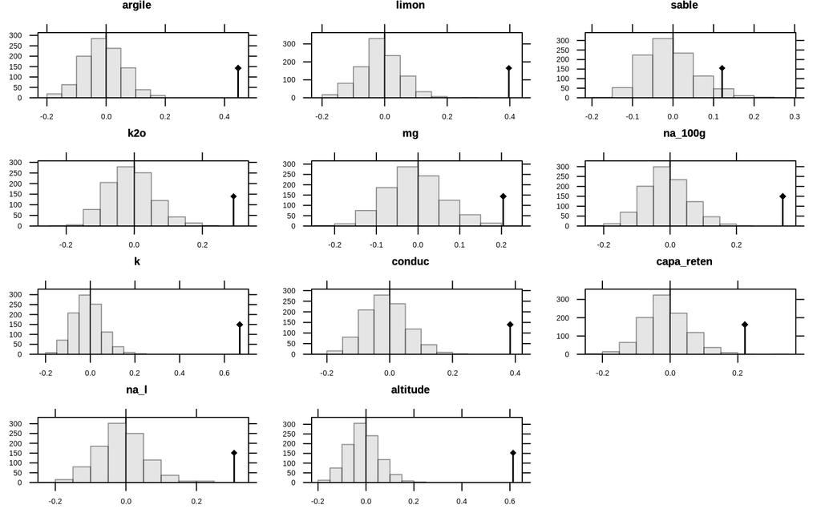

```r
MC_env <- moran.randtest(mil, listwgab, nrepet = 999)
plot(MC_env)
```

Seul le sable ne présente pas d’autocorrélation spatiale. On va sélectionner quelles sont les MEM à conserver pour éviter le surapprentissage. Attention, seul les MEM ayant une autocorrelation positive sont détectés ici, ce qui peut être un incovénient.

```r
pca_hell <- dudi.pca(flo_hell, scale = FALSE, scannf = FALSE, nf = 2)
mem_gab_sel <- mem.select(pca_hell$tab, listw = listwgab)
```

```
## Procedure stopped (alpha criteria): pvalue for variable 14 is 0.053000 (> 0.050000)
```

Maintenant, regardons le partitionnement de la variance.

```r
vp <- varpart(pca_hell$tab, mil, mem_gab_sel$MEM.select)
print(vp)
```

```
##
## Partition of variance in RDA
##
## Call: varpart(Y = pca_hell$tab, X = mil, mem_gab_sel$MEM.select)
##
## Explanatory tables:
## X1:  mil
## X2:  mem_gab_sel$MEM.select
##
## No. of explanatory tables: 2
## Total variation (SS): 77.901
##             Variance: 0.81146
## No. of observations: 97
##
## Partition table:
##                      Df R.squared Adj.R.squared Testable
## [a+b] = X1           11   0.23173       0.13230     TRUE
## [b+c] = X2           13   0.39079       0.29537     TRUE
## [a+b+c] = X1+X2      24   0.47597       0.30130     TRUE
## Individual fractions
## [a] = X1|X2          11                 0.00593     TRUE
## [b]                   0                 0.12638    FALSE
## [c] = X2|X1          13                 0.16899     TRUE
## [d] = Residuals                         0.69870    FALSE
## ---
## Use function 'rda' to test significance of fractions of interest
```

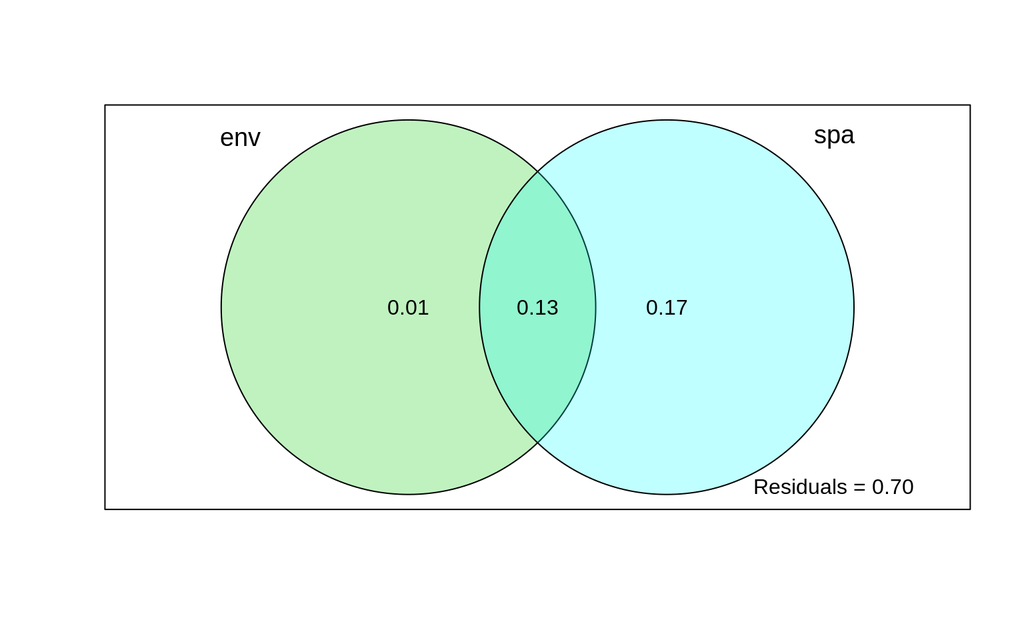

```r
plot(vp, bg = c(3, 5), Xnames = c("env", "spa"))
```

Maintenant, faisons une RDA avec les MEMs sélectionnées.

```r
rda_mem <- rda(flo_hell ~ ., mem_gab_sel$MEM.select)
```

On regarde si la RDA est significative

```r
anova.cca(rda_mem)
```

```
## Permutation test for rda under reduced model
## Permutation: free
## Number of permutations: 999
##
## Model: rda(formula = flo_hell ~ MEM1 + MEM2 + MEM6 + MEM4 + MEM3 + MEM5 + MEM12 + MEM9 + MEM7 + MEM31 + MEM10 + MEM17 + MEM16, data = mem_gab_sel$MEM.select)
##          Df Variance      F Pr(>F)
## Model    13  0.31711 4.0955  0.001 ***
## Residual 83  0.49435
## ---
## Signif. codes:  0 '***' 0.001 '**' 0.01 '*' 0.05 '.' 0.1 ' ' 1
```

```r
rda_mem
```

```
## Call: rda(formula = flo_hell ~ MEM1 + MEM2 + MEM6 + MEM4 + MEM3 +
## MEM5 + MEM12 + MEM9 + MEM7 + MEM31 + MEM10 + MEM17 + MEM16, data =
## mem_gab_sel$MEM.select)
##
##               Inertia Proportion Rank
## Total          0.8115     1.0000
## Constrained    0.3171     0.3908   13
## Unconstrained  0.4944     0.6092   56
## Inertia is variance
##
## Eigenvalues for constrained axes:
##    RDA1    RDA2    RDA3    RDA4    RDA5    RDA6    RDA7    RDA8    RDA9
## 0.13640 0.05117 0.02884 0.02208 0.02034 0.01307 0.01080 0.00947 0.00673
##   RDA10   RDA11   RDA12   RDA13
## 0.00576 0.00488 0.00429 0.00327
##
## Eigenvalues for unconstrained axes:
##     PC1     PC2     PC3     PC4     PC5     PC6     PC7     PC8
## 0.08099 0.04222 0.03657 0.03079 0.02874 0.02226 0.02009 0.01911
## (Showing 8 of 56 unconstrained eigenvalues)
```

Nous n’avons pas besoin de regarder s’il y a de la colinéarité avec entres les MEMs, car par définitions, ils sont tous orthogonaux les uns aux autres.

Enfin, on va regarder les graphiques. Ces RDA sont présentées de manière indicative.

```
##
## -----------------------------------------------------------------------
## Site constraints (lc) selected. To obtain site scores that are weighted
## sums of species scores (default in vegan), argument site.sc must be set
## to wa.
## -----------------------------------------------------------------------
## No factor, hence levels cannot be plotted with symbols; 'plot.centr' is set to FALSE
```

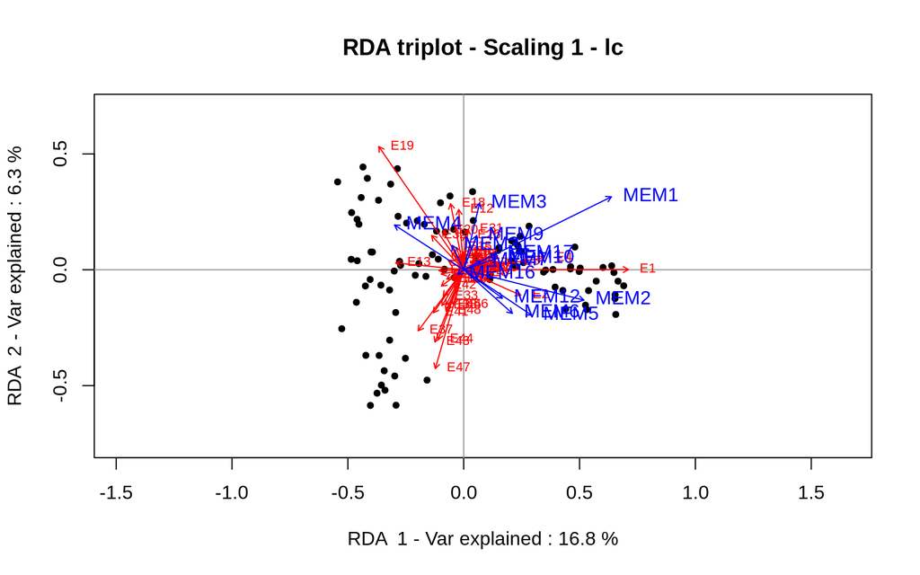

```r
triplot.rda(rda_mem, site.sc = "lc", scaling = 1, label.sites = FALSE)
```

```
##
## -----------------------------------------------------------------------
## Site constraints (lc) selected. To obtain site scores that are weighted
## sums of species scores (default in vegan), argument site.sc must be set
## to wa.
## -----------------------------------------------------------------------
## No factor, hence levels cannot be plotted with symbols; 'plot.centr' is set to FALSE
```

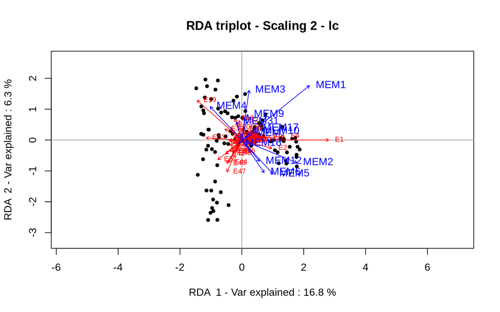

```r
triplot.rda(rda_mem, site.sc = "lc", label.sites = FALSE)
```

On va enlever les espèces les moins bien représentés dans nos ordinations. Le seuil fixé à `> 0.4` est arbitraire et dépend des résultats de `goodness(rda_mem)`. Ces RDA sont présentées de manière indicative.

```
##
## -----------------------------------------------------------------------
## Site constraints (lc) selected. To obtain site scores that are weighted
## sums of species scores (default in vegan), argument site.sc must be set
## to wa.
## -----------------------------------------------------------------------
## No factor, hence levels cannot be plotted with symbols; 'plot.centr' is set to FALSE
```

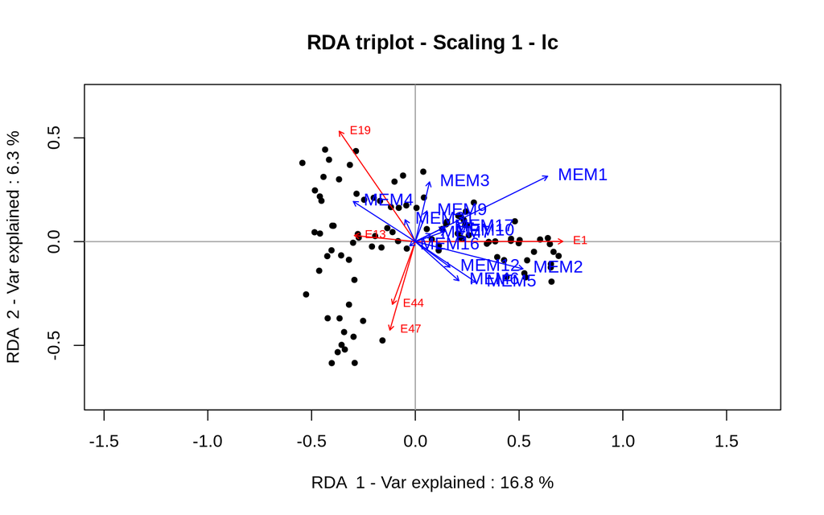

```r
triplot.rda(rda_mem, site.sc = "lc", scaling = 1, label.sites = FALSE, select.spe = goodness(rda_mem, model = "CCA")[, 2] > 0.4)
```

```
##
## -----------------------------------------------------------------------
## Site constraints (lc) selected. To obtain site scores that are weighted
## sums of species scores (default in vegan), argument site.sc must be set
## to wa.
## -----------------------------------------------------------------------
## No factor, hence levels cannot be plotted with symbols; 'plot.centr' is set to FALSE
```

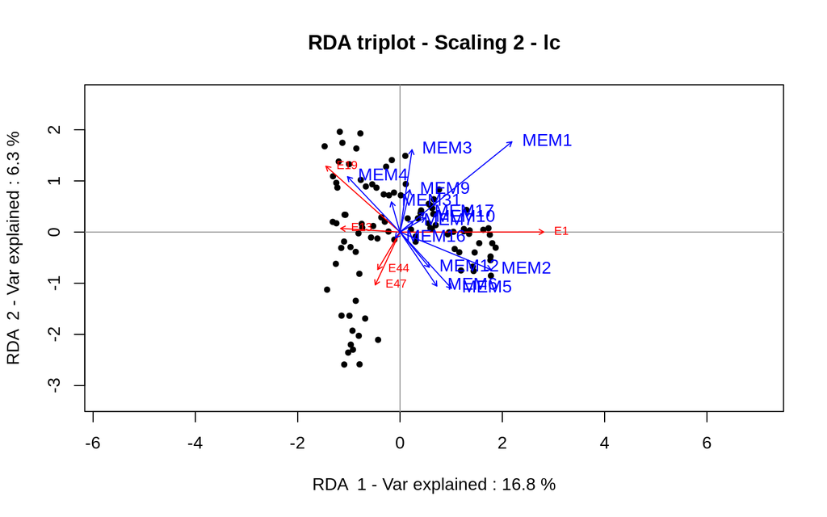

```r
triplot.rda(rda_mem, site.sc = "lc", label.sites = FALSE, select.spe = goodness(rda_mem, model = "CCA")[, 2] > 0.4)
```

## Partie environnemtale

On séléectionne les variable qui maximise le $R^2_{adj}$.

```r
m0 <- rda(flo ~ 1, mil_scl)
m1 <- rda(flo ~ ., mil_scl)

ordiR2step(m0, m1)
```

```
## Step: R2.adj= 0
## Call: flo ~ 1
##
##                 R2.adjusted
## <All variables> 0.137869612
## + k             0.071990171
## + altitude      0.063714978
## + na_100g       0.030066244
## + conduc        0.027443735
## + na_l          0.021976033
## + k2o           0.020093665
## + argile        0.013696866
## + limon         0.010518892
## + mg            0.008371564
## + sable         0.005195094
## + capa_reten    0.004833793
## <none>          0.000000000
##
##     Df    AIC      F Pr(>F)
## + k  1 280.36 8.4472  0.002 **
## ---
## Signif. codes:  0 '***' 0.001 '**' 0.01 '*' 0.05 '.' 0.1 ' ' 1
##
## Step: R2.adj= 0.07199017
## Call: flo ~ k
##
##                 R2.adjusted
## <All variables>  0.13786961
## + altitude       0.10778949
## + sable          0.08086610
## + conduc         0.07988415
## + na_l           0.07941418
## + capa_reten     0.07879842
## + na_100g        0.07847256
## + mg             0.07750330
## + limon          0.07369916
## + k2o            0.07367870
## + argile         0.07352318
## <none>           0.07199017
##
```

[output cut: 47 more lines]

```
## Call: flo ~ k + altitude + capa_reten + mg
##
##                 R2.adjusted
## <All variables>   0.1378696
## + na_100g         0.1323873
## + conduc          0.1323632
## + argile          0.1312941
## + na_l            0.1309842
## + sable           0.1301435
## + limon           0.1298861
## <none>            0.1289764
## + k2o             0.1284264
##
##           Df    AIC      F Pr(>F)
## + na_100g  1 277.66 1.3617  0.146
```

```
## Call: rda(formula = flo ~ k + altitude + capa_reten + mg, data =
## mil_scl)
##
##               Inertia Proportion Rank
## Total         19.0030     1.0000
## Constrained    3.1406     0.1653    4
## Unconstrained 15.8624     0.8347   56
## Inertia is variance
##
## Eigenvalues for constrained axes:
##   RDA1   RDA2   RDA3   RDA4
## 2.2349 0.4765 0.3121 0.1172
##
## Eigenvalues for unconstrained axes:
##   PC1   PC2   PC3   PC4   PC5   PC6   PC7   PC8
## 3.588 1.849 1.670 1.116 0.831 0.706 0.567 0.534
## (Showing 8 of 56 unconstrained eigenvalues)
```

```r
rda_env <- rda(flo_hell ~ k + altitude + capa_reten, mil_scl)
```

Test de notre modèle.

```r
anova.cca(rda_env)
```

```
## Permutation test for rda under reduced model
## Permutation: free
## Number of permutations: 999
##
## Model: rda(formula = flo_hell ~ k + altitude + capa_reten, data = mil_scl)
##          Df Variance      F Pr(>F)
## Model     3  0.11333 5.0323  0.001 ***
## Residual 93  0.69814
## ---
## Signif. codes:  0 '***' 0.001 '**' 0.01 '*' 0.05 '.' 0.1 ' ' 1
```

```r
rda_env
```

```
## Call: rda(formula = flo_hell ~ k + altitude + capa_reten, data =
## mil_scl)
##
##               Inertia Proportion Rank
## Total          0.8115     1.0000
## Constrained    0.1133     0.1397    3
## Unconstrained  0.6981     0.8603   56
## Inertia is variance
##
## Eigenvalues for constrained axes:
##    RDA1    RDA2    RDA3
## 0.08740 0.01472 0.01120
##
## Eigenvalues for unconstrained axes:
##     PC1     PC2     PC3     PC4     PC5     PC6     PC7     PC8
## 0.12350 0.07374 0.05944 0.04446 0.03410 0.03115 0.02834 0.02467
## (Showing 8 of 56 unconstrained eigenvalues)
```

Notre modèle est significatif. Regardons maintenant la colinéarité.

```r
vif.cca(rda_env)
```

```
##          k   altitude capa_reten
##   1.179113   1.158075   1.117180
```

Maintenant, affichons les graphiques. Ces RDA sont présentées de manière indicative.

```
##
## -----------------------------------------------------------------------
## Site constraints (lc) selected. To obtain site scores that are weighted
## sums of species scores (default in vegan), argument site.sc must be set
## to wa.
## -----------------------------------------------------------------------
## No factor, hence levels cannot be plotted with symbols; 'plot.centr' is set to FALSE
```

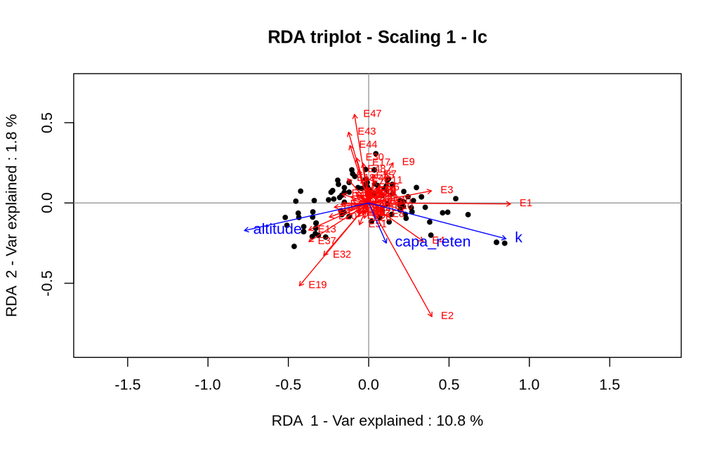

```r
triplot.rda(rda_env, site.sc = "lc", scaling = 1, label.sites = FALSE)
```

```
##
## -----------------------------------------------------------------------
## Site constraints (lc) selected. To obtain site scores that are weighted
## sums of species scores (default in vegan), argument site.sc must be set
## to wa.
## -----------------------------------------------------------------------
## No factor, hence levels cannot be plotted with symbols; 'plot.centr' is set to FALSE
```

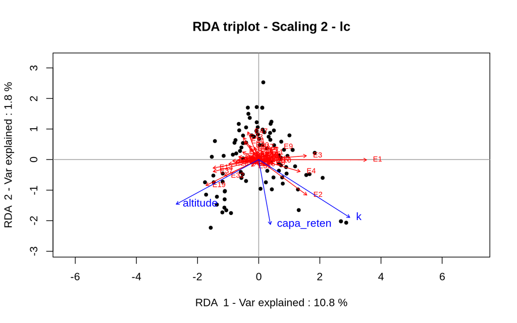

```r
triplot.rda(rda_env, site.sc = "lc", label.sites = FALSE)
```

On va retirer de l’affichage quelques espèces. Ces RDA sont présentées de manière indicative.

```
##
## -----------------------------------------------------------------------
## Site constraints (lc) selected. To obtain site scores that are weighted
## sums of species scores (default in vegan), argument site.sc must be set
## to wa.
## -----------------------------------------------------------------------
## No factor, hence levels cannot be plotted with symbols; 'plot.centr' is set to FALSE
```

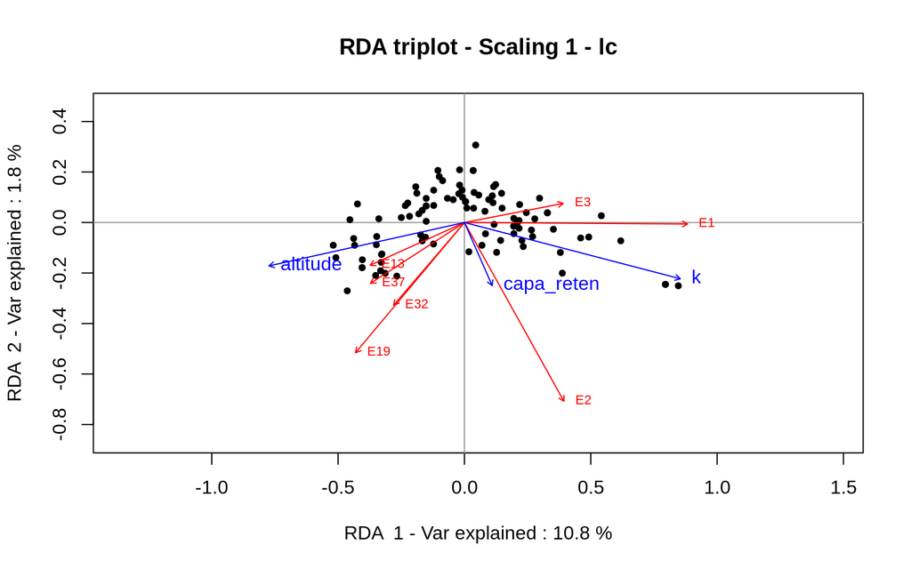

```r
triplot.rda(rda_env, site.sc = "lc", scaling = 1, label.sites = FALSE, select.spe = goodness(rda_env, model = "CCA")[, 2] > 0.15)
```

```
##
## -----------------------------------------------------------------------
## Site constraints (lc) selected. To obtain site scores that are weighted
## sums of species scores (default in vegan), argument site.sc must be set
## to wa.
## -----------------------------------------------------------------------
## No factor, hence levels cannot be plotted with symbols; 'plot.centr' is set to FALSE
```

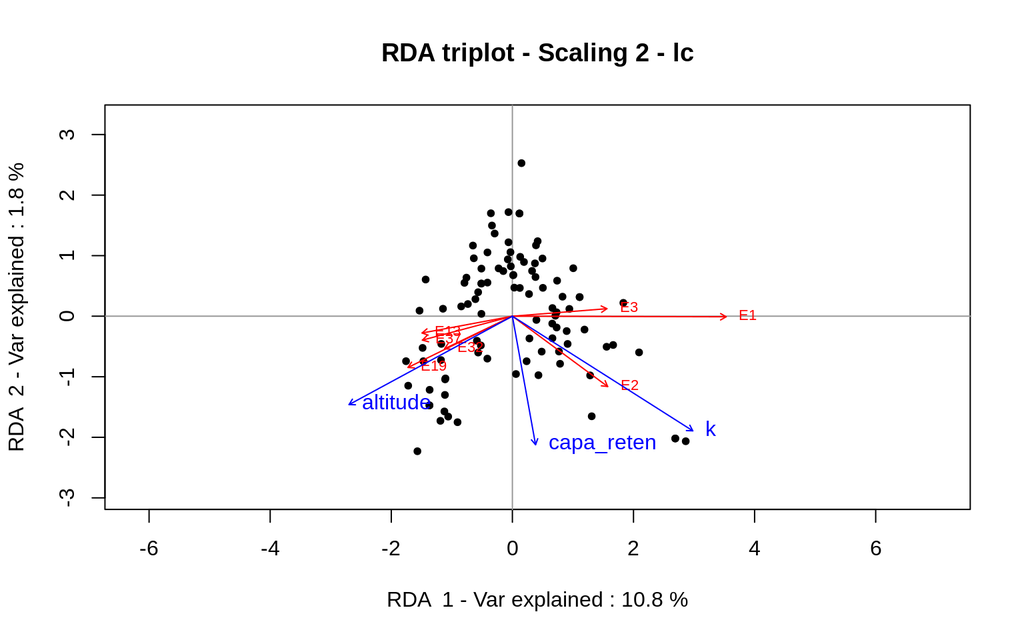

```r
triplot.rda(rda_env, site.sc = "lc", label.sites = FALSE, select.spe = goodness(rda_env, model = "CCA")[, 2] > 0.15)
```

## Mise en commun

On va joindre les deux tableaux (MEMs et variables environnementales utilisées)

```r
env_spa <- mil_scl %>%
  select(k, capa_reten, altitude) %>%
  cbind(mem_gab_sel$MEM.select)
```

La RDA.

```r
rda_envspa <- rda(flo_hell ~ ., env_spa)
```

Vérification de la significativé.

```r
anova.cca(rda_envspa)
```

```
## Permutation test for rda under reduced model
## Permutation: free
## Number of permutations: 999
##
## Model: rda(formula = flo_hell ~ k + capa_reten + altitude + MEM1 + MEM2 + MEM6 + MEM4 + MEM3 + MEM5 + MEM12 + MEM9 + MEM7 + MEM31 + MEM10 + MEM17 + MEM16, data = env_spa)
##          Df Variance      F Pr(>F)
## Model    16  0.34226 3.6472  0.001 ***
## Residual 80  0.46920
## ---
## Signif. codes:  0 '***' 0.001 '**' 0.01 '*' 0.05 '.' 0.1 ' ' 1
```

```r
rda_envspa
```

```
## Call: rda(formula = flo_hell ~ k + capa_reten + altitude + MEM1 +
## MEM2 + MEM6 + MEM4 + MEM3 + MEM5 + MEM12 + MEM9 + MEM7 + MEM31 +
## MEM10 + MEM17 + MEM16, data = env_spa)
##
##               Inertia Proportion Rank
## Total          0.8115     1.0000
## Constrained    0.3423     0.4218   16
## Unconstrained  0.4692     0.5782   56
## Inertia is variance
##
## Eigenvalues for constrained axes:
##    RDA1    RDA2    RDA3    RDA4    RDA5    RDA6    RDA7    RDA8    RDA9
## 0.14030 0.05239 0.03010 0.02255 0.02091 0.01681 0.01241 0.01001 0.00747
##   RDA10   RDA11   RDA12   RDA13   RDA14   RDA15   RDA16
## 0.00632 0.00533 0.00496 0.00421 0.00355 0.00312 0.00181
##
## Eigenvalues for unconstrained axes:
##     PC1     PC2     PC3     PC4     PC5     PC6     PC7     PC8
## 0.07763 0.03926 0.03124 0.03072 0.02701 0.02166 0.01962 0.01860
## (Showing 8 of 56 unconstrained eigenvalues)
```

Notre modèle est significatif.

```
##
## -----------------------------------------------------------------------
## Site constraints (lc) selected. To obtain site scores that are weighted
## sums of species scores (default in vegan), argument site.sc must be set
## to wa.
## -----------------------------------------------------------------------
## No factor, hence levels cannot be plotted with symbols; 'plot.centr' is set to FALSE
```

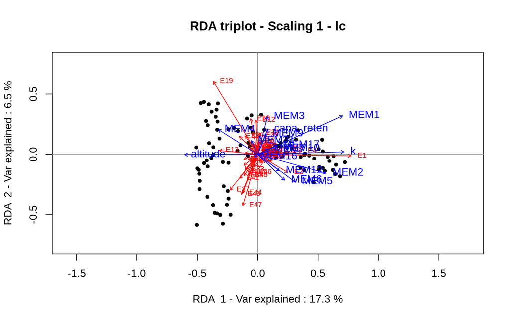

```r
triplot.rda(rda_envspa, site.sc = "lc", scaling = 1, label.sites = FALSE, plot.centr = FALSE)
```

```
##
## -----------------------------------------------------------------------
## Site constraints (lc) selected. To obtain site scores that are weighted
## sums of species scores (default in vegan), argument site.sc must be set
## to wa.
## -----------------------------------------------------------------------
## No factor, hence levels cannot be plotted with symbols; 'plot.centr' is set to FALSE
```

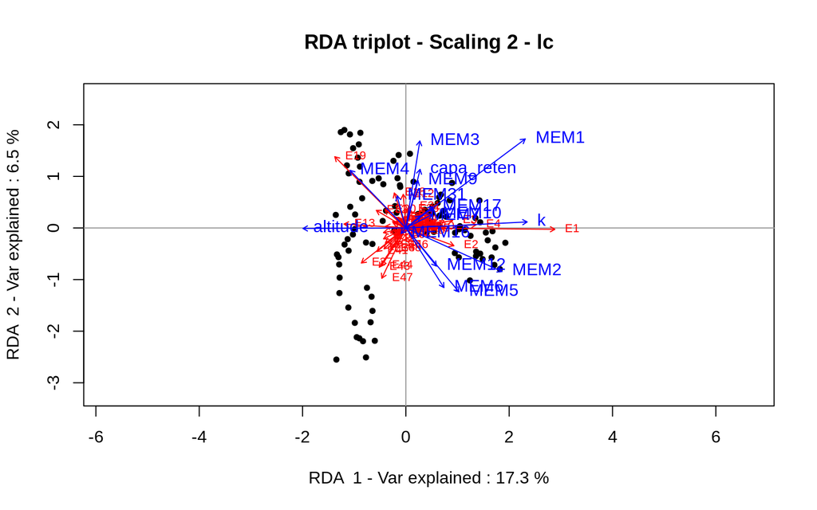

```r
triplot.rda(rda_envspa, site.sc = "lc", label.sites = FALSE, plot.centr = FALSE)
```

On va retirer de l’affichage quelques espèces.

```
##
## -----------------------------------------------------------------------
## Site constraints (lc) selected. To obtain site scores that are weighted
## sums of species scores (default in vegan), argument site.sc must be set
## to wa.
## -----------------------------------------------------------------------
## No factor, hence levels cannot be plotted with symbols; 'plot.centr' is set to FALSE
```

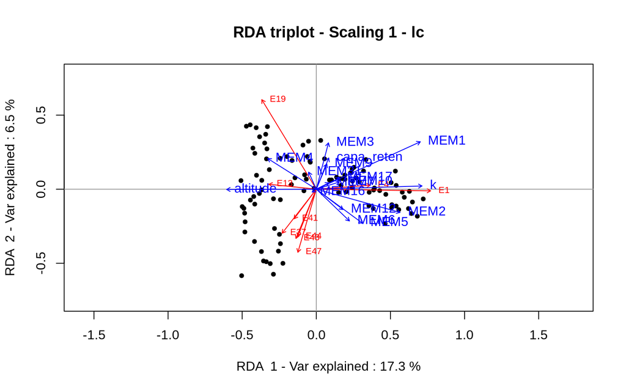

```r
triplot.rda(rda_envspa, site.sc = "lc", scaling = 1, label.sites = FALSE, select.spe = goodness(rda_envspa, model = "CCA")[, 2] > 0.3)
```

```
##
## -----------------------------------------------------------------------
## Site constraints (lc) selected. To obtain site scores that are weighted
## sums of species scores (default in vegan), argument site.sc must be set
## to wa.
## -----------------------------------------------------------------------
## No factor, hence levels cannot be plotted with symbols; 'plot.centr' is set to FALSE
```

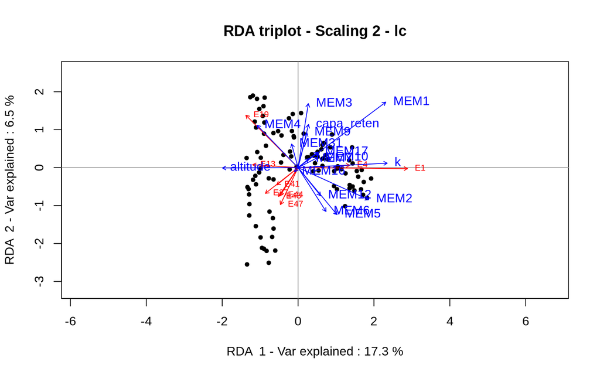

```r
triplot.rda(rda_envspa, site.sc = "lc", label.sites = FALSE, select.spe = goodness(rda_envspa, model = "CCA")[, 2] > 0.3)
```

Si nous nous intéressons maintenant aux autres variables environnementales, il est possible d’observer que la majorité des espèces les mieux représentées dans notre ordination sont des espèces qui vivent dans des sites où la capacité de rétention en eau est faible. L’espèce E1 est une espèce très fortement corrélée à la concentration en potassium, c’est donc une espèce plutôt halophile. Au contraire, l’espèce E13 est négativement corrélée avec la présence de potassium, c’est donc une espèce halophobe. Enfin le groupe d’espèce en bas à gauche de l’ordination (E41, E43, E44, E47, etc.) sont corrélés avec positivement avec l’altitude, mais négativement avec la capacité de rétention en eau. Ce sont des espèces que l’on va retrouver plutôt à l’arrière du front de mer sur un sol sec.

Enfin la capacité de rétention en eau des sols est relativement indépendante de la concentration en potassium et de l’altitude. Nous supposons que cet effet est dû à la composition différente des sols qui ferait que par exemple, certains sols plus hauts en altitude contiennent plus d’eau que d’autres plus bas.

Pour conclure notre modèle montre que notre communautés est majoritairement structurés par des variables spatiales, ici représenté par des MEMs. La communauté floristique est structurée dans une moins grande mesure par trois variables environnementales : la concentration en potassium, la capacité de rétention en eau et l’altitude. Le fait que les variables spatiales représentent la majeur partie de la variance expliquée n’est pas étonnant : chaque zone géographique représente une niche écologique et sélectionne les mêmes types de communauté floristique.

Benoit DAVIET

Julien LOMBARD

Keyvin RAYNAL

Olaloudé Judicaël OSSE

Julien ROCHE

Clément VIOLET

29/10/2019